# Business Statistics Mid-Term Assessment IB94X0 2024-2025 #1

# Section 2

#A structured summary table for quick reference.

```r
# Loading necessary libraries
library(knitr)
library(dplyr)

# Creating a summary table for weekday and weekend footfall
# Load necessary libraries
library(knitr)

# Create a summary table with t-test results for weekdays and weekends
summary_table <- data.frame(
  Location = c("Coney Street", "Stonegate"),
  Weekday_Mean = c(20817.45, 19204.09),
  Weekend_Mean = c(25863.37, 26166.96)



)

# Display the summary table
kable(summary_table, caption = "Summary of Footfall Statistics for Coney Street and Stonegate",
      col.names = c("Location", "Mean Footfall (Weekdays)", "Mean Footfall (Weekends)"))
```

Summary of Footfall Statistics for Coney Street and Stonegate

[output not shown]

A statistical analysis was carried out to compare footfall trends between these two venues on weekdays and weekends.

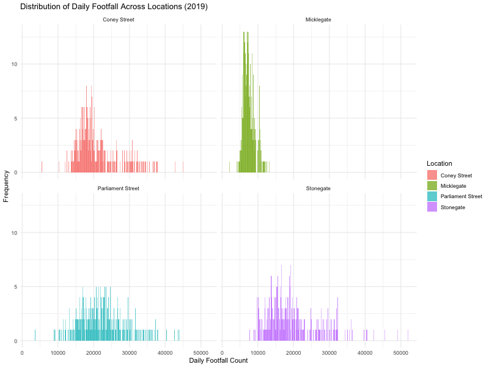

```r
knitr::include_graphics("histogram_footfall_2019.png")
```

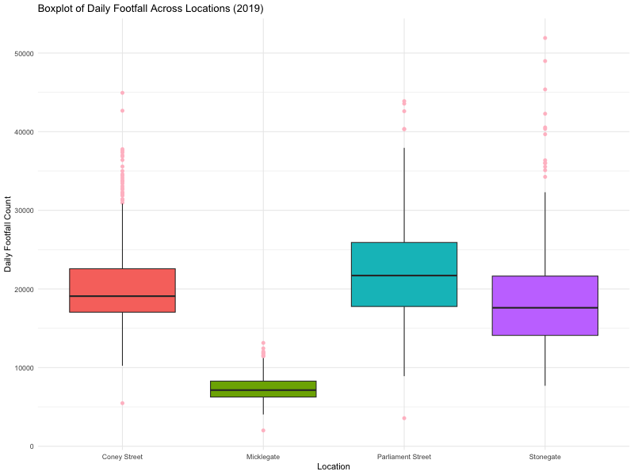

```r
knitr::include_graphics("boxplot_footfall_2019.png")
```

*Weekend Footfall Comparison*: On weekends, the footfall averages on Coney Street (25,863.37) and Stonegate (26,166.96) are statistically comparable, with no significant difference. As a result, either location might be picked during weekends, as both are expected to have equivalent foot traffic levels.

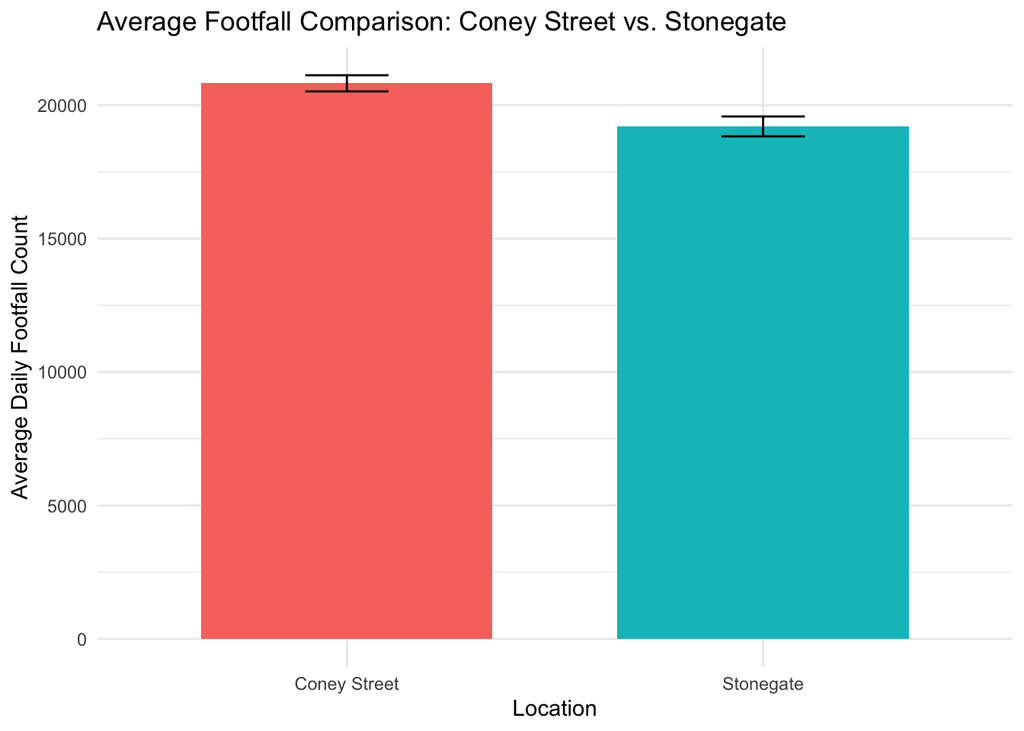

```r
# Loading necessary libraries
library(ggplot2)
library(dplyr)

# Preparinging the data for bar plot
# Calculating means and standard errors for footfall counts
#The code calculates the mean and standard error (SE) of the footfall counts for each location. This helps in visualizing the average while accounting for variability.
summary_data <- York_footfall_coney_stonegate %>%
  group_by(LocationName) %>%
  summarise(
    Mean_Footfall = mean(TotalCount),
    SE = sd(TotalCount) / sqrt(n())
  )

# Creating a bar plot with error bars
#The geom_bar() function creates bars representing the average footfall for Coney Street and Stonegate, while geom_errorbar() adds error bars to show the uncertainty around the mean estimates.
ggplot(summary_data, aes(x = LocationName, y = Mean_Footfall, fill = LocationName)) +
  geom_bar(stat = "identity", position = position_dodge(), width = 0.7) +
  geom_errorbar(aes(ymin = Mean_Footfall - SE, ymax = Mean_Footfall + SE),
                width = 0.2, position = position_dodge(0.7)) +
  labs(title = "Average Footfall Comparison: Coney Street vs. Stonegate",
       x = "Location",
       y = "Average Daily Footfall Count",
       fill = "Location") +
  theme_minimal() +
  theme(legend.position = "none")
```

*Recommendations:* By presenting the average footfall counts with error bars in this manner, we can understand the footfall patterns and can further make discussion on how to optimize operations, marketing efforts, or crowd management strategies based on observed footfall trends.

*Weekend Placement:* For weekend days, either Coney Street or Stonegate would be appropriate for stall placement, allowing for additional logistical considerations such as space and accessibility.

*These recommendations are based on robust data comparisons and provide an opportunity to strategically maximise footfall engagement for promotional initiatives.*

Declaration of use of AI: AI used: ChatGPT

*Why AI was used*: ChatGPT was employed to ensure code functionality, enhance the quality of data presentation, and support the effective use of R Markdown for visualizations.

*What AI was used for*: 1. To debug and rectify errors within the code while validating the quality and integrity of the dataset. 2. To learn methods for embedding images in R Markdown files, including the syntax for saving plots with ggsave() and png() and using include_graphics() for final report presentation. 3. To explore plotting techniques (histogram, boxplot, and density plot) for representing footfall distribution across locations, including understanding which plot types are most appropriate for various aspects of the data. 4. To gain insights into possible visualization approaches in R to ensure the results are presented clearly and professionally.

*Which AI was used:* ChatGPT by OpenAI.

*Use of generated content in submission:* *No content generated by AI has been directly* included in this submission. The AI tool was utilized purely for guidance and learning purposes in code implementation, visualization decisions, and presentation techniques.